# lmg5 Linear Regression R Package

Preston R. Graben, Jessica Hofstetter, Yida Bao

### Description

The following file describes how our package lmg5 was written and how to use it. The top of this document describes what all the parameters are and what the output will be. You can also see how these things are calculated by reading the comments found within the R code. At the very bottom of this document you will find an example of how to use the function as well as what the outputs are.

The package can be found on github in the AU-R-Programming repository. Inside the project is saved in the final_project_G5 repository. To download this package from github, copy and paste the following code into the console of your RStudio session: devtools::install_github(“AU-R-Programming/final_project_G5”)

Be sure to remember to include library(lmg5) in your code when you wish to use the lmg5 function.

### Parameters

Parameter - response - A vector of length n to denote response variable.

Parameter - covariate - A matrix of dimension n*p denoting covariate.

Parameter - alpha A number used to denote the significance level.

### This function returns the following attributes:

beta - Estimated coefficients

sigma2 - Estimated variance

variance_beta - variance of beta

ci - Confidence interval

r2 - Goodness of fit

Cp - Mallows’ Cp

Fteststat - F-test statistic

pvalue - p-value of F-test statistic

plot of residuals

qq-plot of residuals

residuals histograms plot

```r
library(ggplot2)
#Function to minimize to achieve beta estimate
beta_hat_func = function(y, x, beta){

    return((t(y-as.matrix(x)%*%beta))%*%(y-as.matrix(x)%*%beta))
}
my_lm = function(response, covariates, alpha = 0.05) {

  # Make sure data formats are appropriate
  response <- as.vector(response)
  covariates <- as.matrix(covariates)

  # Define parameters
  n <- length(response)
  p <- dim(covariates)[2]
  df <- n - p

  # Estimate beta through optimization()
  x= covariates
  x<- cbind(1,x)
  covariates = x
  y= response
  beta_zero<- NA
  p<- dim(x)[2]
  beta_zero[1] <- mean(y)

  #continuing to fill in beta_zero
  for (i in 2:p) {
    beta_zero[i]<- cov(y,x[,i])/var(x[,i])
  }

  #make sure that beta hat function works for y x and betazero
  beta_hat_func(y,x,beta_zero)
  betahat_optimize<- optim(beta_zero, function (z) beta_hat_func(y,x,z))
  beta.hat<- betahat_optimize $par

  # Estimate of the residual variance (sigma2) from Eq. (6.3)
  # Compute residuals
  resid <- response - covariates%*%as.matrix(beta.hat)
  sigma2.hat <- (1/df)*t(resid)%*%resid

  # Estimate of the variance of the estimated beta from Eq. (6.2)
  var.beta <- as.numeric(sigma2.hat)*solve(t(covariates)%*%covariates)

  # Estimate of the confidence interval based on alpha
  quant <- 1 - alpha/2
  ci.beta <- c(beta.hat - qnorm(p = quant)*sqrt(var.beta), beta.hat +
                 qnorm(p = quant)*sqrt(var.beta))
  # Estimate yhat
  yhat<- x %*% as.matrix(beta.hat)

  #calulate SSE
  SSE<- sum((y-yhat)^2)

  #calculate SST
  SST<- sum((y-mean(y))^2)

  #Calulate R^2
  Rsquared<- 1-(SSE/SST)

  #calculate Cp
  cp<- SSE + 2*p*sigma2.hat

  #calculate DFM
  DFM<- p-1

  #calculate DFE
  DFE<- n-p

  #calculate SSM
  SSM<- sum((yhat-mean(y))^2)

  #calculate MSM
  MSM<- SSM/DFM

  #calculate MSE
  MSE<- SSE/ DFE

  #calculate Fstar
  fstar<- MSM/MSE

  #calculate fpvalue
  fpvalue<- pf(fstar,DFM, DFE)

  #Plot residuals vs yhat
  resid_vs_fitted <- ggplot() + geom_point(aes(x= yhat, y= resid))

  plot(resid_vs_fitted)

  # Plot qq-plot of residuals
  qqnorm(resid)

  # Histogram of residuals
  hist(resid)

  # Return all estimated values
  return(list(beta = beta.hat, sigma2 = sigma2.hat,
              variance_beta = var.beta, ci = ci.beta, r2= Rsquared, Cp= cp, Fteststat= fstar, pvalue= fpvalue ))
}
```

# Example

Here we will show an example of how to use the function as well as show the outputs that the function returns.

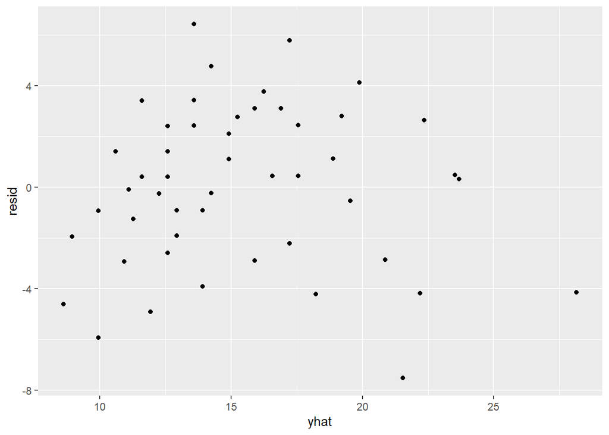

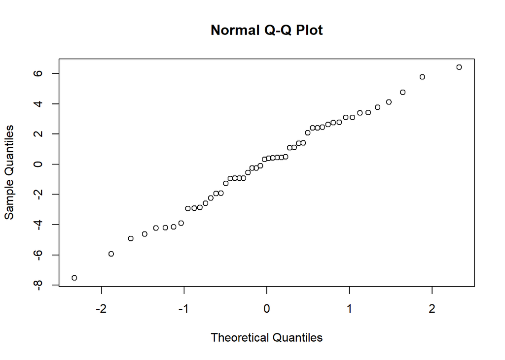

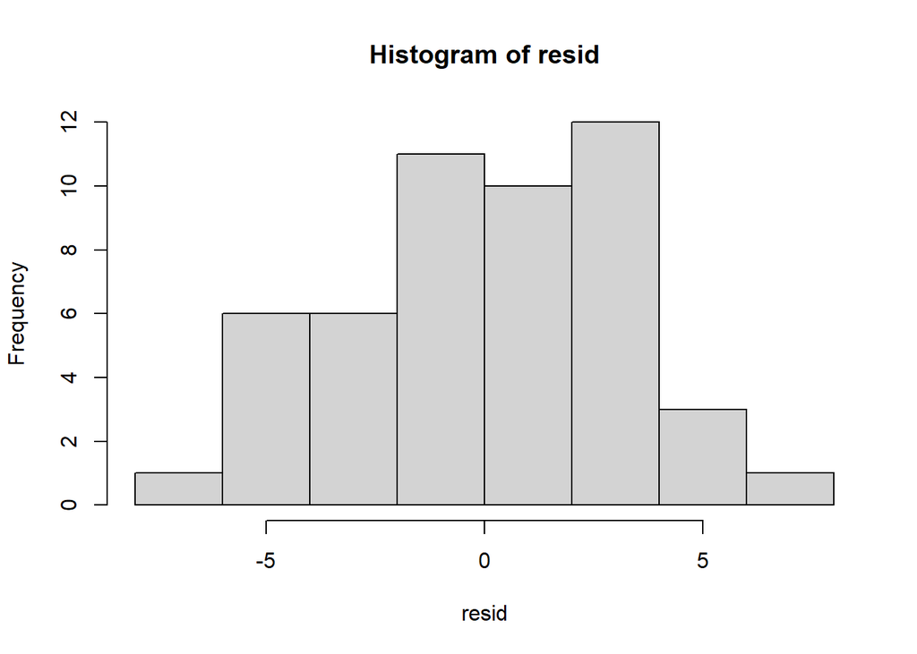

```
## $beta
## [1] 8.2828959 0.1656021
##
## $sigma2
##          [,1]
## [1,] 9.755537
##
## $variance_beta
##             [,1]          [,2]
## [1,]  0.74894530 -0.0128858670
## [2,] -0.01288587  0.0002998108
##
## $ci
## [1] 7.6991815       NaN       NaN 0.1539233 8.8666103       NaN       NaN
## [8] 0.1772809
##
## $r2
## [1] 0.6510793
##
## $Cp
##          [,1]
## [1,] 517.0434
##
## $Fteststat
## [1] 89.60443
##
## $pvalue
## [1] 1
```

```r
#Example about Data cars
library(lmg5)
data(cars)
lmg5(cars$speed, cars$dist, alpha = 0.5)
```